# Python 简易教程 (lecture for Solar Group)

### Matplotlib

- 官方示例 https://matplotlib.org/tutorials/index.html

[figure not shown]

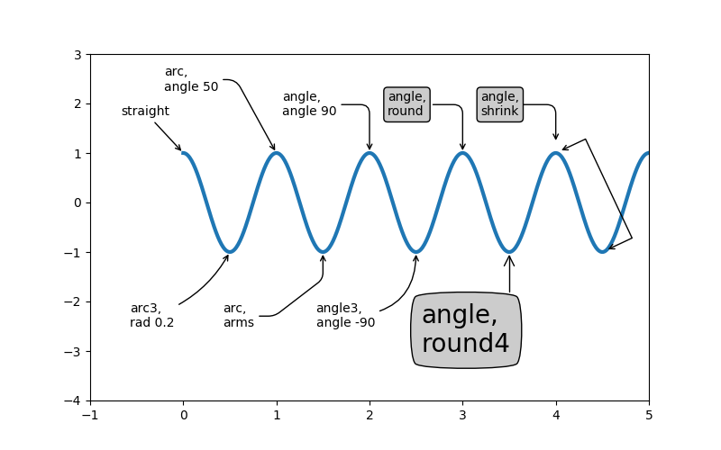

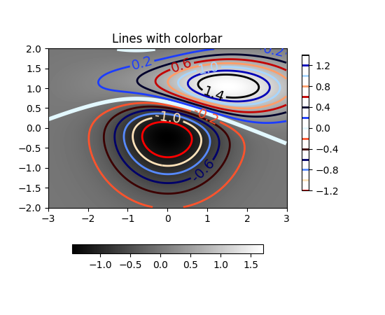

- 官方教程 https://matplotlib.org/tutorials/introductory/usage.html

```python
import matplotlib.pyplot as plt
```

创建一个图像 (三种写法皆可):

```python
fig, ax = plt.subplots()
```

```python
fig = plt.figure(1, (12, 6), dpi=100)
ax = fig.add_subplot(111)  # 数字 (ijk) 表示: 这是一共i行j列中的组图中的第k个图
```

```python
fig = plt.gcf()
ax = plt.gca()
```

获取帮助:

```python
help(ax)
```

```python
# 查看某对象包含的方法
ax.# <Tab>, <Shift-Tab>
plt.# <Tab>, <Shift-Tab>
```

例:

```python
%matplotlib?
```

```python
%matplotlib
%run -e 'examples/test_plot.py'
```

```python
%matplotlib
%run -e 'examples/test_imshow.py'
```

- 颜色 https://matplotlib.org/examples/color/colormaps_reference.html
- legend https://matplotlib.org/users/legend_guide.html

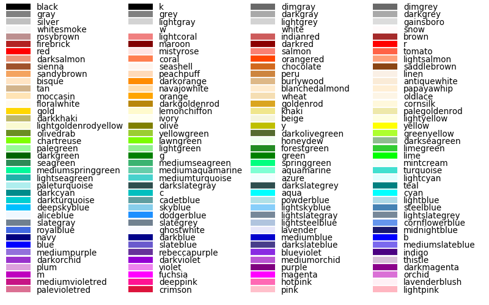

### 天文相关包

#### Astropy

[figure not shown]

官方文档 http://docs.astropy.org/en/stable/index.html

坐标系统 http://docs.astropy.org/en/stable/coordinates/index.html

```
from astropy import units as u
from astropy.coordinates import SkyCoord
```

参考 https://python4astronomers.github.io/astropy/astropy.html

#### SunPy

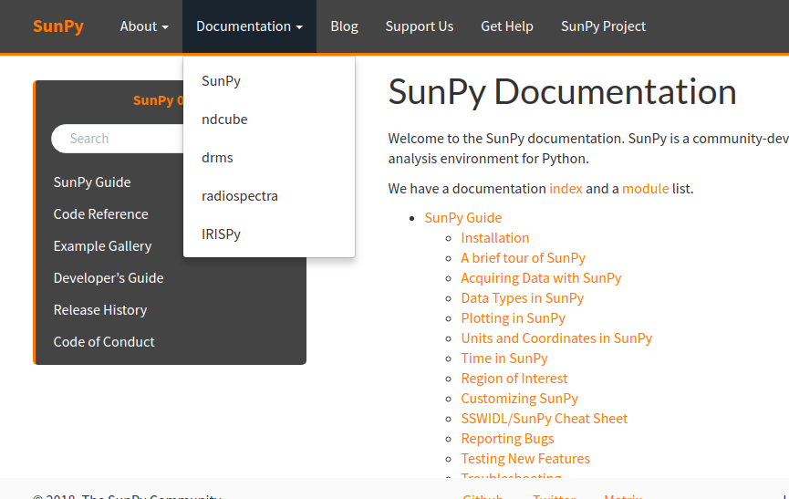

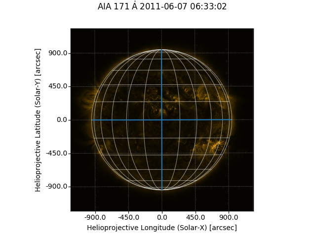

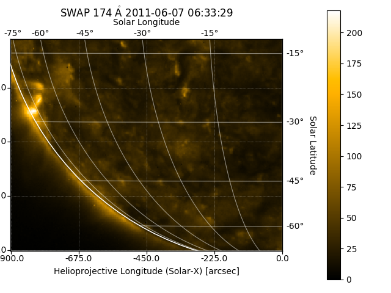

HMI 示例见 [Python 进阶#SunPy 示例] (advance.ipynb#SunPy-示例)

https://github.com/lydiazly/scripts-sunpy

参考:

- Gallery http://docs.sunpy.org/en/stable/generated/gallery/index.html
- SunPy Guide http://docs.sunpy.org/en/stable/guide/index.html
- SunPy Map  
  http://docs.sunpy.org/en/stable/code_ref/map.html#sunpy.map.mapbase.GenericMap
- Example Gallery http://docs.sunpy.org/en/stable/generated/gallery/index.html
- A brief tour of SunPy http://docs.sunpy.org/en/stable/guide/tour.html
- Finding and Downloading Data using Fido  
  http://docs.sunpy.org/en/stable/guide/acquiring_data/fido.html

简单的例子(来自官网):

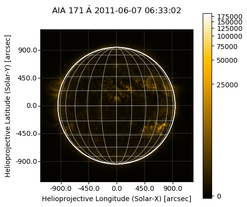

```python
%matplotlib inline

import sunpy.map
import matplotlib.pyplot as plt
import sunpy.data.sample

aia = sunpy.map.Map(sunpy.data.sample.AIA_171_IMAGE)

fig = plt.figure(1, (5, 5), dpi=100)
ax = plt.subplot(111, projection=aia)

aia.plot()
aia.draw_limb()
aia.draw_grid()
aia.draw_limb()
plt.colorbar();

# plt.show()
```

获取一些常数:

```python
from sunpy.sun import constants as con
# one astronomical unit (the average distance between the Sun and Earth)
print(con.au)
```

```
  Name   = Astronomical Unit
  Value  = 149597870700.0
  Uncertainty  = 0.0
  Unit  = m
  Reference = IAU 2012 Resolution B2
```

```python
# the solar radius
print(con.radius)
```

```
  Name   = Solar radius
  Value  = 695508000.0
  Uncertainty  = 26000.0
  Unit  = m
  Reference = Allen's Astrophysical Quantities 4th Ed.
```

## 常见数据文件读写

### 一般情况

```
f = open(filename, 'w')  # 'w', 'r', ...
...
...
f.close()
```

更好的用法:

```
with open(filename, 'w') as f:  # 'w', 'r', ...
    ...
    ...
```

### txt, csv 文件读写

- 逐行读取整行的方式:  
  使用 `strip` 可以用来去掉读入的每行末尾的 '\n'

```python
lines = []
with open('data/data.csv', 'r') as f:
    for line in f:
        lines.append(line.strip().split(','))
lines
```

```
[['col1', 'col2', 'col3'],
 ['row1', '1', '1e1'],
 ['row2', '2', '2e-1'],
 ['row3', '3', '3e+2']]
```

- 使用 numpy, 读取后直接转成数组的方式 (推荐):  
  `np.loadtxt`, `np.genfromtxt` (写文件是 `np.savetxt`)  
  超大文件读取建议用 pandas 包.

e.g.

```
>>> import numpy as np
>>> arr = np.loadtxt(fname, skiprows=1, delimiter=',') # 默认分割符为空格
>>> col1, col2 = np.loadtxt(fname, skiprows=1, usecols=(1, 2), unpack=True)
```

`np.genfromtxt` 和 `np.loadtxt` 类似, 增加了处理 missing values 的功能.  
(但参数 skiprows=1 需替换为 skip_header=1)

例 (这里使用功能更多的 `np.genfromtxt` 代替 `np.loadtxt`):

```python
arr = np.genfromtxt('data/data.csv',
                    skip_header=1,
                    names=('col1', 'col2', 'col3'),
                    dtype=('U15', 'int', 'float'),
                    delimiter=',')
print(arr[['col1', 'col2']])  # 设定了 names 之后, 可以用名称索引
```

```
[('row1', 1) ('row2', 2) ('row3', 3)]
```

```python
arr = np.genfromtxt('data/data2.csv',
                    skip_header=1,
                    names=('col1', 'col2', 'col3'),
                    dtype=('U15', 'int', 'float'),
                    missing_values=None,
                    filling_values=('', 0, np.nan),  # 分开指定
                    delimiter=',')
print(arr)
```

```
[('row1', 0, 10. ) ('', 2,  0.2) ('row3', 3,  nan)]
```

- 一般而言, 对于一个由分隔符分隔的字符串, 转成一个数组的方式:  
  `np.fromstring(string, dtype=float, count=-1, sep='')`

```python
np.fromstring('0 1 2', dtype=int, sep=' ')
```

```
array([0, 1, 2])
```

```python
np.fromstring('0., 1., 2.', sep=',')
```

```
array([0., 1., 2.])
```

### numpy save 文件读写

```
np.save('fname', arr)  # 'fname.npy'
np.savez('fname', arr)  # 'fname.npz', 多个变量
np.savez_compressed('fname', arr)  # 'fname.npz', 多个变量 & 压缩
np.load('fname.npz')  # Load the files created by savez_compressed.
```

```python
# 存入
arr = np.ones(5)  # 默认 `float64`
np.savez('data/np_array', a=arr, b=0)
```

```python
ls data/*.npz
```

```
data/np_array.npz
```

```python
# 载入
data = np.load('data/np_array.npz')
print((data['a'], data['b'], int(data['b'])))  # 默认以`ndarray`读取
```

```
(array([1., 1., 1., 1., 1.]), array(0), 0)
```

### IDL sav 文件读取

```
from scipy.io.idl import readsav
data = readsav('dname.sav', verbose=True, python_dict=False)
```

默认读出的是`scipy.io.idl.AttrDict`类型, 即 key 的大小写不敏感.  
想要得到大小写敏感的 python dict, 设置 `python_dict=True` 即可.  
例:

```python
from scipy.io.idl import readsav
data = readsav('data/myidlfile.sav')
print(type(data))
print(data.keys())  # 注意返回的是一个`dict_keys`对象, 如需索引需要手动转为list
print(data['X'].shape)  # 大小写不敏感
data = readsav('data/myidlfile.sav', python_dict=True)
print(type(data))
print(data['x'].shape)  # 大小写敏感
```

```
<class 'scipy.io.idl.AttrDict'>
dict_keys(['x', 'y', 'str'])
(25,)
<class 'dict'>
(25,)
```

### FITS 文件读取

- Astropy

参考:  
http://docs.astropy.org/en/stable/io/fits  
https://python4astronomers.github.io/astropy/fits.html

> [Note]  
> If you are already familiar with PyFITS, astropy.io.fits is in fact the same code as the latest version of PyFITS, and you can adapt old scripts that use PyFITS to use Astropy by simply doing:

> ```
> from astropy.io import fits as pyfits
> ```

> However, for new scripts, we recommend the following import:

> ```
> from astropy.io import fits
> ```

`fits.open`

```
>>> from astropy.io import fits
>>> hdulist = fits.open('<filename>.fit')
>>> hdulist.info()  # hdulist 是一个由 HDU objects 组成的类似列表的对象
Filename: <filename>.fit
No.    Name         Type      Cards   Dimensions   Format
0    PRIMARY     PrimaryHDU    ...       ...        ...
1    ENERGIES    BinTableHDU   ...       ...        ...
>>> hdu = hdulist[0]
>>> hdu.data  # ndarray
>>> hdu.header['<key>']  # 得到某个 header keyword
# 修改数据后
>>> hdu.writeto('<filename>.fits') # 保存 HDU object
>>> hdulist.writeto('<filename>.fits')  # 或保存整个表
```

```
# 创建一个 fits Primary HDU object
>>> hdu = fits.PrimaryHDU()
>>> hdu.writeto('<filename>.fits')  # 保存 HDU object
>>> hdu.writeto('<filename>.fits', clobber=True)  # 保存到已存在文件
```

`fits.getdata`, `fits.getheader`

```
>>> data = fits.getdata('<filename>.fit')
>>> header = fits.getheader('<filename>.fit')
```

- SunPy

```
>>> import sunpy.io
>>> hdulist = sunpy.io.read_file('<filename>.fits')  # 自动判断文件类型
# or use `hdulist = sunpy.io.fits.read('<filename>.fits')`
>>> hdu = hdulist[1]
>>> hdu.data  # ndarray
```

```
>>> import sunpy.map
>>> smap = sunpy.map.Map('<filename>.fits')
# 得到一个 sunpy `GenericMap` object
```

例:

```python
from astropy.io import fits
fname = 'scripts-sunpy/plothmi/data/hmi.B_720s.20150827_052400_TAI.field.fits'
hdulist = fits.open(fname)
```

```python
hdulist.info()
```

```
Filename: scripts-sunpy/plothmi/data/hmi.B_720s.20150827_052400_TAI.field.fits
No.    Name      Ver    Type      Cards   Dimensions   Format
  0  PRIMARY       1 PrimaryHDU       6   ()
  1                1 CompImageHDU    155   (4096, 4096)   int32
```

```python
hdulist.verify('silentfix+warn')
hdu = hdulist[1]
hdu.data.shape
```

```
(4096, 4096)
```

```python
import sunpy.io
hdulist = sunpy.io.read_file(fname)
hdu = hdulist[1]
hdu.data.shape
```

```
(4096, 4096)
```

## 其他包和软件

- Astroconda https://astroconda.readthedocs.io/en/latest/

  > AstroConda is a free Conda channel maintained by the Space Telescope Science Institute (STScI) in Baltimore, Maryland. This channel provides tools and utilities required to process and analyze data from the Hubble Space Telescope (HST), James Webb Space Telescope (JWST), and others.
- PyCharm https://www.jetbrains.com/pycharm/

[figure not shown]

- Jupyterlab http://jupyterlab.readthedocs.io/en/stable/

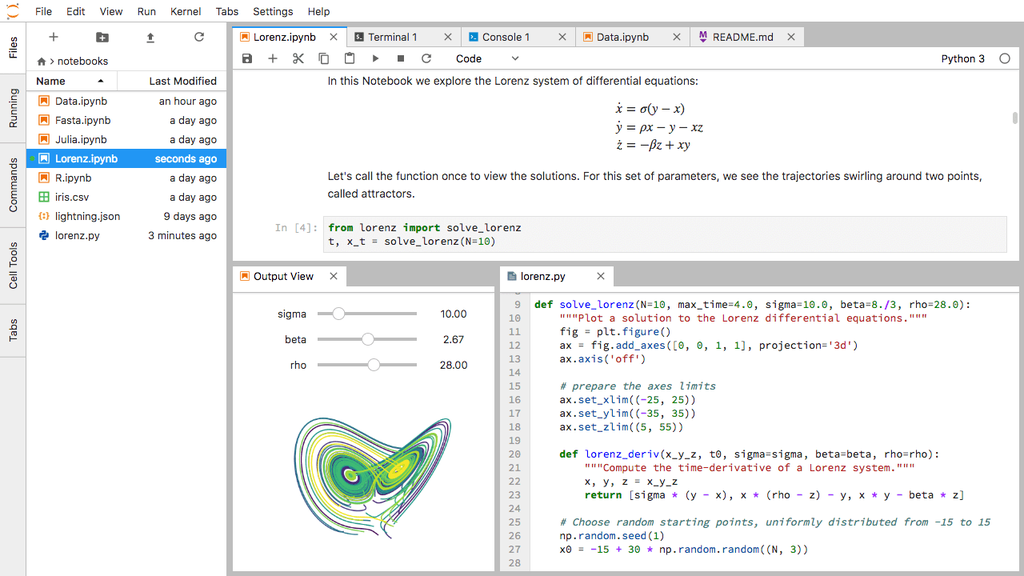